# Deep Learning x Software Engineering

```python
pip install git+https://github.com/tensorflow/examples.git
```

[output not shown]

```python
from tensorflow_examples.models.pix2pix import pix2pix

from IPython.display import clear_output
import matplotlib.pyplot as plt
```

```python
import tensorflow as tf

import tensorflow_datasets as tfds
```

### How to build an efficient big data pipeline

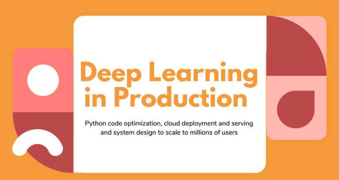

We will incrementally explore the following concepts and ideas:

> How to structure and develop production-ready machine learning code,

> How to optimize the model’s performance and memory requirements, and

> How to make it available to the public by setting up a small server on the cloud.

### From Research to Production

> 1. Setup your laptop and environment.
> 2. Best practices to structure your python code and develop the model.
> 3. Optimize the performance of the code in terms of latency, memory etc.
> 4. Train the model in the cloud.
> 5. Build an API to serve the model.
> 6. Containerize and deploy the model in the cloud.
> 7. Scale it to handle loads of traffic.

Technologies used:

> Python, Pycharm, Anaconda, Tensorflow, Git and Github, Flask, WSGI, Docker, Kubernetes, Google Cloud and probably much more.

### Project Description

- For the basis of our project, we will use an official tutorial form Tensorflow in which the authors use a slightly modified U-Net to perform image segmentation.
- Semantic segmentation is the task of assigning a label to every pixel of an image based on its context. This is super useful because it enables computers to understand what they see. And I’m confident you can think of many applications that would be helpful. Some of them include autonomous cars, robotics and medical imaging.

#### MODEL ALGORITHM

> A well known model that is used in image segmentation are UNets. UNets are symmetric convolutional neural networks that consist of an encoder and a decoder. But instead of being a linear shaped model, every layer of the encoder connects with a layer of the decoder via skip connections. The result is to have a U shaped Network, hence their name.

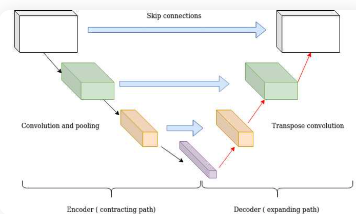

- The motivation behind this type of skip connections is that they have an uninterrupted gradient flow from the first layer to the last layer, which tackles the vanishing gradient problem. Concatenative skip connections enable an alternative way to ensure feature reusability of the same dimensionality from the earlier layers and are widely used.
- On the other hand, long skip connections are used to pass features from the encoder path to the decoder path in order to recover spatial information lost during downsampling. Short skip connections appear to stabilize gradient updates in deep architectures. Finally, skip connections enable feature reusability and stabilize training and convergence.

## U-Net Algorithm example

### Download he Oxford -IIIT Pets Dataset

```python
dataset, info = tfds.load('oxford_iiit_pet:3.*.*', with_info=True)
```

```
Downloading and preparing dataset 773.52 MiB (download: 773.52 MiB, generated: 774.69 MiB, total: 1.51 GiB) to /Users/josue/tensorflow_datasets/oxford_iiit_pet/3.2.0...
```

```
Dataset oxford_iiit_pet downloaded and prepared to /Users/josue/tensorflow_datasets/oxford_iiit_pet/3.2.0. Subsequent calls will reuse this data.
```

```python
def normalize(input_image, input_mask):
  input_image = tf.cast(input_image, tf.float32) / 255.0
  input_mask -= 1
  return input_image, input_mask
```

```python
def load_image(datapoint):
  input_image = tf.image.resize(datapoint['image'], (128, 128))
  input_mask = tf.image.resize(
    datapoint['segmentation_mask'],
    (128, 128),
    method = tf.image.ResizeMethod.NEAREST_NEIGHBOR,
  )

  input_image, input_mask = normalize(input_image, input_mask)

  return input_image, input_mask
```

The dataset already contains the required training and test splits, so continue to use the same splits:

```python
TRAIN_LENGTH = info.splits['train'].num_examples
BATCH_SIZE = 64
BUFFER_SIZE = 1000
STEPS_PER_EPOCH = TRAIN_LENGTH // BATCH_SIZE
```

```python
train_images = dataset['train'].map(load_image, num_parallel_calls=tf.data.AUTOTUNE)
test_images = dataset['test'].map(load_image, num_parallel_calls=tf.data.AUTOTUNE)
```

The following class performs a simple augmentation by randomly-flipping an image. Go to the Image augmentation tutorial to learn more.

```python
class Augment(tf.keras.layers.Layer):
  def __init__(self, seed=42):
    super().__init__()
    # both use the same seed, so they'll make the same random changes.
    self.augment_inputs = tf.keras.layers.RandomFlip(mode="horizontal", seed=seed)
    self.augment_labels = tf.keras.layers.RandomFlip(mode="horizontal", seed=seed)

  def call(self, inputs, labels):
    inputs = self.augment_inputs(inputs)
    labels = self.augment_labels(labels)
    return inputs, labels
```

Build the input pipeline, applying the augmentation after batching the inputs:

```python
train_batches = (
    train_images
    .cache()
    .shuffle(BUFFER_SIZE)
    .batch(BATCH_SIZE)
    .repeat()
    .map(Augment())
    .prefetch(buffer_size=tf.data.AUTOTUNE))

test_batches = test_images.batch(BATCH_SIZE)
```

Visualize an image example and its corresponding mask from the dataset:

```python
def display(display_list):
  plt.figure(figsize=(15, 15))

  title = ['Input Image', 'True Mask', 'Predicted Mask']

  for i in range(len(display_list)):
    plt.subplot(1, len(display_list), i+1)
    plt.title(title[i])
    plt.imshow(tf.keras.utils.array_to_img(display_list[i]))
    plt.axis('off')
  plt.show()
```

[figure not shown]

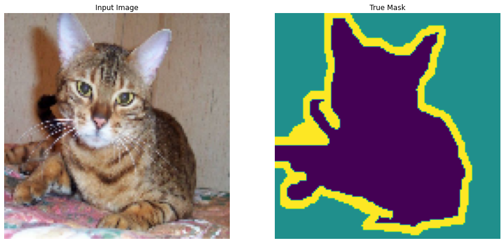

```python
for images, masks in train_batches.take(2):
  sample_image, sample_mask = images[0], masks[0]
  display([sample_image, sample_mask])
```

### Train the model

When running inference, the label assigned to the pixel is the channel with the highest value. This is what the `create mask` function is doing.

```python
OUTPUT_CLASSES = 3

model = unet_model(output_channels=OUTPUT_CLASSES)
model.compile(optimizer='adam',
              loss=tf.keras.losses.SparseCategoricalCrossentropy(from_logits=True),
              metrics=['accuracy'])
```

```python
#Plot the resulting model architecture:

tf.keras.utils.plot_model(model, show_shapes=True)
```

```
You must install pydot (`pip install pydot`) and install graphviz (see instructions at https://graphviz.gitlab.io/download/) for plot_model to work.
```

[figure not shown]

```python
#Try out the model to check what it predicts before training:

def create_mask(pred_mask):
  pred_mask = tf.math.argmax(pred_mask, axis=-1)
  pred_mask = pred_mask[..., tf.newaxis]
  return pred_mask[0]
```

```python
def show_predictions(dataset=None, num=1):
  if dataset:
    for image, mask in dataset.take(num):
      pred_mask = model.predict(image)
      display([image[0], mask[0], create_mask(pred_mask)])
  else:
    display([sample_image, sample_mask,
             create_mask(model.predict(sample_image[tf.newaxis, ...]))])
```

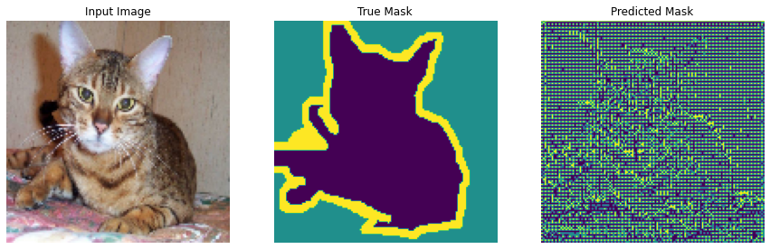

```python
show_predictions()
```

The callback defined below is used to observe how the model improves while it is training:

```python
class DisplayCallback(tf.keras.callbacks.Callback):
  def on_epoch_end(self, epoch, logs=None):
    clear_output(wait=True)
    show_predictions()
    print ('\nSample Prediction after epoch {}\n'.format(epoch+1))
```

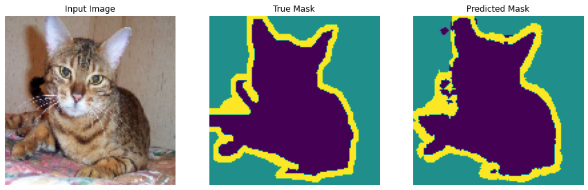

```
Sample Prediction after epoch 20
```

```python
EPOCHS = 20
VAL_SUBSPLITS = 5
VALIDATION_STEPS = info.splits['test'].num_examples//BATCH_SIZE//VAL_SUBSPLITS

model_history = model.fit(train_batches, epochs=EPOCHS,
                          steps_per_epoch=STEPS_PER_EPOCH,
                          validation_steps=VALIDATION_STEPS,
                          validation_data=test_batches,
                          callbacks=[DisplayCallback()])
```

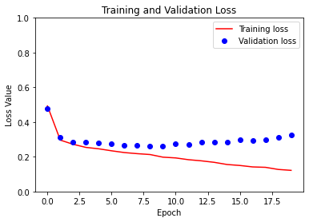

```python
loss = model_history.history['loss']
val_loss = model_history.history['val_loss']

plt.figure()
plt.plot(model_history.epoch, loss, 'r', label='Training loss')
plt.plot(model_history.epoch, val_loss, 'bo', label='Validation loss')
plt.title('Training and Validation Loss')
plt.xlabel('Epoch')
plt.ylabel('Loss Value')
plt.ylim([0, 1])
plt.legend()
plt.show()
```

### Make Predictions

Now, make some predictions. In the interest of saving time, the number of epochs was kept small, but you may set this higher to achieve more accurate results.

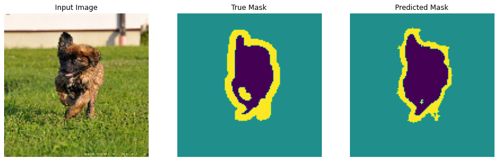

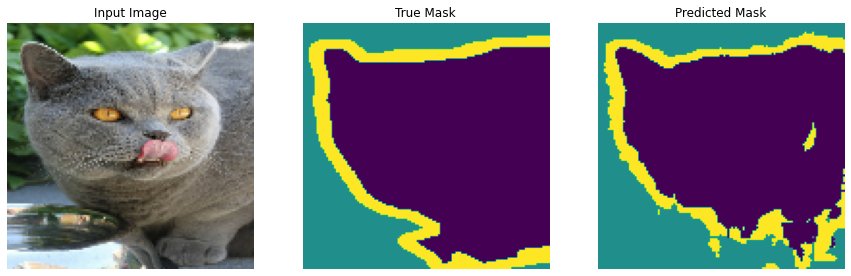

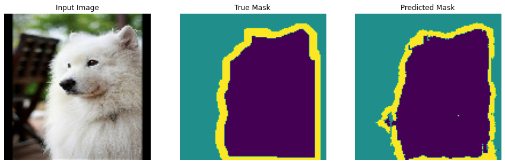

```python
show_predictions(test_batches, 3)
```

### Citations

@article{adaloglou2020skip, title = "Intuitive Explanation of Skip Connections in Deep Learning", author = "Adaloglou, Nikolas", journal = "https://theaisummer.com/", year = "2020", url = "https://theaisummer.com/skip-connections/" }

## Setting up the environment/system for Deep Learning

> So, why use Python? Why do we need a server? Why run on the cloud and not locally? Why do we need GPUs? Why writing unit tests?

### High level architecture

$Objective$:

> Let’s assume that we have a website and for some reason we want to add an image segmentation functionality on that page. So the user will navigate to that page, click on a button to upload an image and then we will display back the result after we perform the segmentation.

> In terms of software, the flow is something like this: the user uploads the image to the browser, the browser sends the image to our backend, the UNet predicts the segmented image and we send the image back to the user’s browser, where it is rendered.

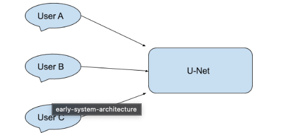

#### Many questions that come to mind:

What will happen if many users ask the model at the same time?

What will happen if for some reason the model crashes?

If it contains a bug we haven’t previously seen?

If the model is too slow and the user has to wait for too long to get a response?

And how can we update our model?

Can we retrain it on new data?

Can we get some feedback if the model performs well?

Can we see how fast or slow the model is?

How much memory does it use?

Where do we store the model weights?

What about the training data?

What if the user sends a malicious request instead of a proper image?

Final Architecture (a whole start up blueprint):

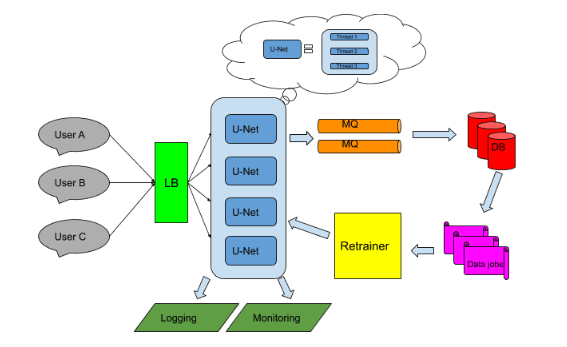

#### Software design principles

`Separation of concerns`: The system should be modularized into different components with each component being a separate maintainable, reusable and extensible entity.

`Scalability`: The system needs to be able to scale as the traffic increases

`Reliability`: The system should continue to be functional even if there is software of hardware failure

`Availability`: The system needs to continue operating at all times

`Simplicity`: The system has to be as simple and intuitive as possible

$ User Process: $

Each user sends a request to our backend. To be able to handle all the simultaneous requests, first we need a `Load Balancer (LB)` to handle the traffic and route the requests to the proper server instance.

We **maintain** more than one instance of the model in order to achieve both `scalability` and `availability`. Note that these might be physical instances, virtual machines or docker containers and they are organized by a distributed system orchestrator (such as Kubernetes)

As you can probably see, each instance may have more than one threads or `parallel processes`. We need that to make sure that the model is fast enough to return a response in real time.

A major problem most machine learning systems face is retraining because in order for the model to stay up to date, you should constantly **update the model weights based on the new data**. In our case, this pipeline consists of:

- A database (DB) to save the requests, the responses and all relative data >
- A message queue (MQ) to send them in the database in an asynchronous manner ( to keep the system reliable and available) >
- Data jobs to preprocess and transform the data in the correct format so that can be used from our model >
- Retrainer instances that execute the actual training based on the saved data

After retraining the model, the new version will gradually replace all the UNet instances. That way we build `deep learning models versioning functionality`, where we **always update the model with the newest version**.

Finally, we need some sort of monitoring and logging to have a complete image of what’s happening in our system, to catch errors quickly and to discover bottlenecks easily.

#### Get ready for Software Engineering

1.Setting up your laptop and installing the tools that we will need throughout the course

2.understand the whys of a modern deep learning system.

> The **first** one is a low effort, kind of boring job that will increase your productivity and save you some time down the road so we can focus only on the software. The **second** one requires some mental effort because deep learning architectures are rather complex systems. But the main thing that you need to remember are the 5 principles as they will accompany us down the road.